# Randomized All Pairs Shortest Paths

Charles Zheng

05/11/2015

# Requirements

The following libraries must be installed:

```r
library(Rcpp)
library(pracma)
```

# Introduction

Let $A$ be an $n \times n$ symmetric weighted adjacency matrix, with $A_{ij} = \begin{cases} 0 & \text{ if }i = j\\ A_{ij} & \text{ if there is an edge from $i$ to $j$,}\\ \infty & \text{ if there is no edge from $i$ to $j$} \end{cases}$

# Min-plus multiplication

For $X_{n \times k}$, $Y_{k \times m}$, define $X \otimes Y = Z_{n \times m}$ by: $Z_{ij} = \min_{l = 1}^k X_{ik} + Y_{kj}$

The code for min-plus is as follows

```r
library(Rcpp)
cppFunction('
NumericMatrix minplus(NumericMatrix Ar, NumericMatrix Br) {
  int n = Ar.nrow();
  int l = Ar.ncol();
  int m = Br.ncol();
  NumericMatrix ans(n, m);
  for (int i = 0; i < n; i++) {
    for (int j = 0; j < m; j++) {
      for (int k = 0; k < l; k++) {
        double x = Ar(i, k) + Br(k, j);
        if (x < ans(i, j) || k == 0) {
          ans(i, j) = x;
        }
      }
    }
  }
  return ans;
}
'
)
```

## Demo

Create a geometric graph on the unit square.

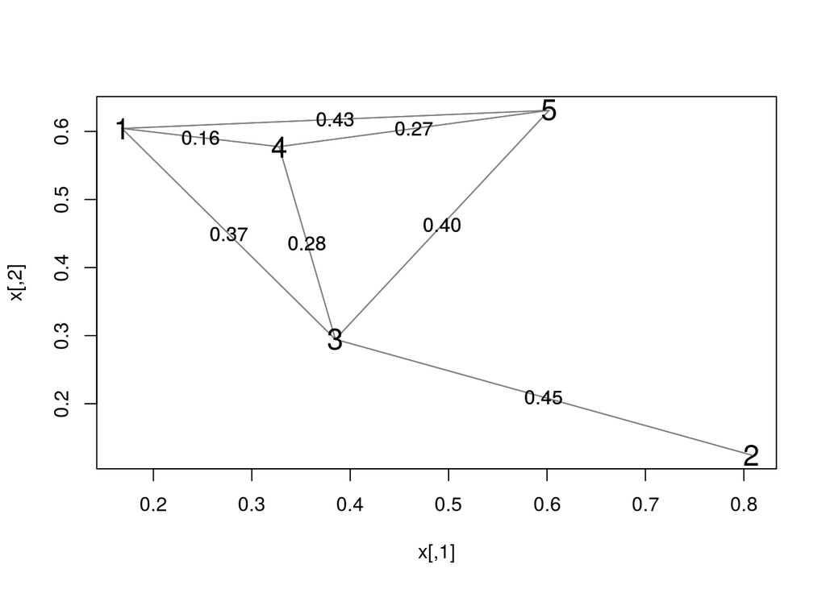

```r
set.seed(3)
n <- 5
eps <- 0.5
x <- matrix(runif(n * 2), n, 2)
dm <- distmat(x, x)
adj <- (dm < eps) + 0
plot(x, pch = ".")
for (i in 1:n) {
  for (j in 1:n) {
    if (adj[i,j] == 1) {
      lines(x[, 1][c(i, j)], x[, 2][c(i, j)], col = gray(.5))
      mid <- (x[i, ] + x[j, ])/2
      if (i != j) text(mid[1], mid[2], substr(paste(dm[i, j]), 0, 4))
    }
  }
}
for (i in 1:n) points(x[i, 1], x[i, 2], pch = paste(i), cex = 1.5)
```

Form the weighted graph matrix $A$ in the format specified previously.

```r
A <- dm * adj
A[A == 0] <- Inf
diag(A) <- 0
A
```

```
##           [,1]      [,2]      [,3]      [,4]      [,5]
## [1,] 0.0000000       Inf 0.3781769 0.1619234 0.4348725
## [2,]       Inf 0.0000000 0.4554753       Inf       Inf
## [3,] 0.3781769 0.4554753 0.0000000 0.2887332 0.4003850
## [4,] 0.1619234       Inf 0.2887332 0.0000000 0.2795088
## [5,] 0.4348725       Inf 0.4003850 0.2795088 0.0000000
```

The shortest length 2 path from node 1 to 2 should be

```r
A2 <- minplus(A, A)
A2[1, 2]
```

```
## [1] 0.8336522
```

Is this correct…? Check the plot.

# Floyd-Warshall and Iterative Squaring

All-pairs shortest paths can either be computed by iterative squaring or Floyd-Warshall

## Iterative squaring

Iterative squaring uses $log(n)$ iterations and costs $n^3$ per iteration.

Each iterate of the algorithm performs the following:

$A \leftarrow A \otimes A$

Code:

```r
iter_square <- function(a) {
  n <- dim(a)[1]
  n_its <- ceiling(log(n)/log(2))
  for (i in 1:n_its) a <- minplus(a, a)
  a
}
```

## Floyd-Warshall

Floyd-Warshall uses $n$ iterations and costs $n^2$ per iteration.

Let $A_k$ denote the $k$ th column of $A$ The $k$ th iteration of Floyd-Warshall computes

$A \leftarrow min(A, A_k \otimes A_k^T)$

Code:

```r
floyd_warshall <- function(a) {
  n <- dim(a)[1]
  for (k in 1:n) {
    Ak <- a[, k, drop = FALSE]
    a <- pmin(a, minplus(Ak, t(Ak)))
  }
  a
}
```

## Demo

Check that both give the same result

```r
A_is <- iter_square(A)
A_fw <- floyd_warshall(A)
sum(A_is != A_fw)
```

```
## [1] 0
```

# Generalizing Floyd-Warshall

Both Floyd-Warshall and iterated squaring can be viewed as generalizations of the same algorithm, “block Floyd-Warshall”. Let $k$ be a block size such that $mk = n$. Then let $A = [B_1, B_2, ..., B_m]$ where each $B_i$ is $n \times k$.

Block Floyd-Warshall has $L$ main iterations. Within each main iterate, there are $m$ subiterations, where on the $i$th subiterate, $A \leftarrow \min(A, B_i \otimes B_i^T)$

- Floyd-Warshall is the special case where $L=1$ and $k = 1$.
- Iterated squaring is the special case where $L = \log(n)$ and $k = n$.
- What about intermediate cases of $L$, $k$??

The number of iterations is $Lm$ and the cost per iteration is $n^2 k$. In general, block Floyd-Warshall will *not* compute the correct all-pairs-shortest-paths matrix. So why should we care? See the writeup `apsp_theory.pdf`.

Code is as follows:

```r
block_fw <- function(a, k, l) {
  n <- dim(a)[1]
  m <- ceiling(n/k)
  for (main_it in 1:l) {
    for (i in 1:m) {
      Bi <- a[, ((i-1) * k + 1):min(n, i * k), drop = FALSE]
      a <- pmin(a, minplus(Bi, t(Bi)))
    }
  }
  a
}
```

## Demo

Compare block FW with $k= 2$ and $L = 1$ to the correct distance matrix

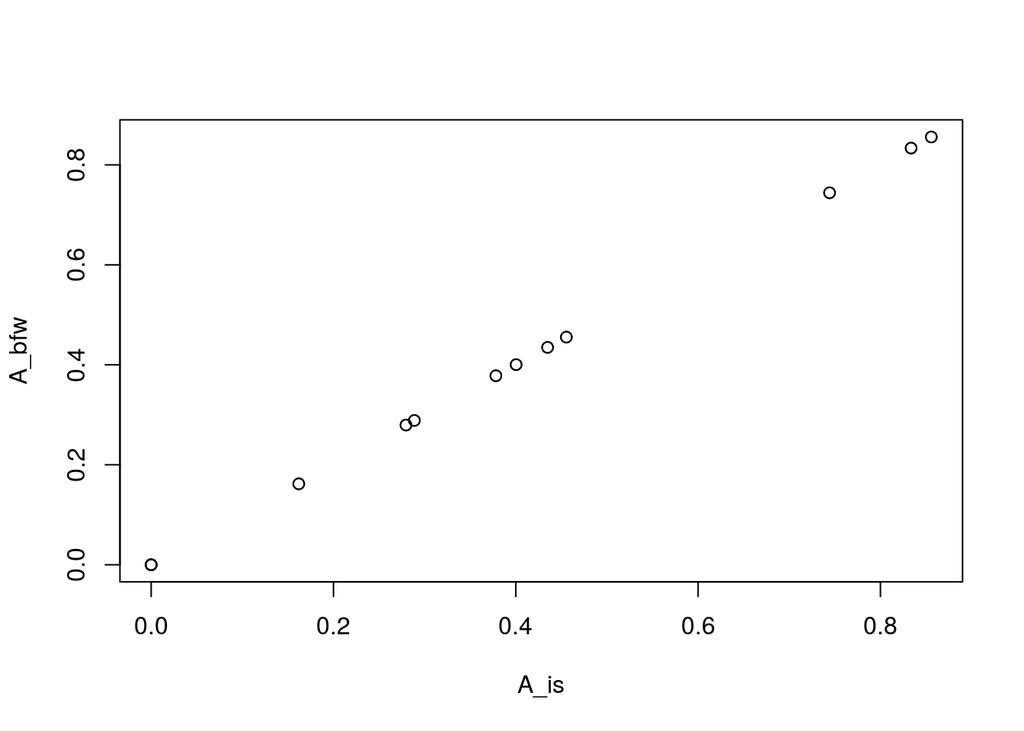

```r
A_bfw <- block_fw(A, 2, 1)
plot(A_is, A_bfw)
```

In this case, it is exact.

# Next

See the writeup `apsp_theory.pdf` and the R markdown `block_fw.Rmd`.